# IJohnson Mod04 QFISH Assignment

Ivanya Johnson

20-09-2024

# QFish Shark Control Program Data

To download data go to: https://qfish.fisheries.qld.gov.au/query/number-caught-by-area-calendar-year-and-species-group/table

## Install and Load Packages

Be sure to install the following packages if they are not already installed.

```r
# install.packages("janitor")
# install.packages("ggmap")

library(janitor)
library(tidyverse)
```

```r
library(readr)
library(ggplot2)
library(ggthemes)
```

## Load Data

```r
totalcatch <- # Name data frame
  read_csv("Shark Catch.csv") |> # Select data to import
  row_to_names(row_number = 2, remove_rows_above = FALSE) |> # Select the row to use for variable names of data frame.
  clean_names() # Creates unique names for the variables. If not included, R will give variables with common names the same name
```

```
## ──────────────────────────────────────────────────────── Delimiter: "," chr
## (122): ...1, CalendarYear, ...3, ...5, ...6, ...7, ...8, ...9, ...10, ..... lgl
## (1): SpeciesGroup
```

```r
head(totalcatch) # Look at data
```

```
## # A tibble: 6 × 123
##   area   mammal other na    shark turtle na_2  mammal_2 other_2 shark_2 turtle_2
##   <chr>  <chr>  <chr> <lgl> <chr> <chr>  <chr> <chr>    <chr>   <chr>   <chr>
## 1 <NA>   2001   2001  NA    2001  2001   2001… 2002     2002    2002    2002
## 2 Bribi… <NA>   <NA>  NA    <NA>  <NA>   <NA>  <NA>     <NA>    <NA>    <NA>
## 3 Bunda… <NA>   1     NA    62    12     75    <NA>     3       62      7
## 4 Cairns 1      16    NA    79    4      100   <NA>     18      46      6
## 5 Capri… <NA>   3     NA    87    <NA>   90    <NA>     4       91      2
## 6 Glads… <NA>   <NA>  NA    32    <NA>   32    <NA>     1       18      1
## # ℹ 112 more variables: na_3 <chr>, mammal_3 <chr>, other_3 <chr>,
## #   shark_3 <chr>, turtle_3 <chr>, na_4 <chr>, mammal_4 <chr>, other_4 <chr>,
## #   shark_4 <chr>, turtle_4 <chr>, na_5 <chr>, mammal_5 <chr>, other_5 <chr>,
## #   shark_5 <chr>, turtle_5 <chr>, na_6 <chr>, mammal_6 <chr>, other_6 <chr>,
## #   shark_6 <chr>, turtle_6 <chr>, na_7 <chr>, mammal_7 <chr>, other_7 <chr>,
## #   shark_7 <chr>, turtle_7 <chr>, na_8 <chr>, mammal_8 <chr>, other_8 <chr>,
## #   shark_8 <chr>, turtle_8 <chr>, na_9 <chr>, mammal_9 <chr>, other_9 <chr>, …
```

```r
totalcatch <- subset(totalcatch, select = -(na_2)) # Removing empty column

summary(totalcatch) # Summary of the data
```

```
##      area              mammal             other              na
##  Length:15          Length:15          Length:15          Mode:logical
##  Class :character   Class :character   Class :character   NA's:15
##  Mode  :character   Mode  :character   Mode  :character
##     shark              turtle            mammal_2           other_2
##  Length:15          Length:15          Length:15          Length:15
##  Class :character   Class :character   Class :character   Class :character
##  Mode  :character   Mode  :character   Mode  :character   Mode  :character
##    shark_2            turtle_2             na_3             mammal_3
##  Length:15          Length:15          Length:15          Length:15
##  Class :character   Class :character   Class :character   Class :character
##  Mode  :character   Mode  :character   Mode  :character   Mode  :character
##    other_3            shark_3            turtle_3             na_4
##  Length:15          Length:15          Length:15          Length:15
##  Class :character   Class :character   Class :character   Class :character
##  Mode  :character   Mode  :character   Mode  :character   Mode  :character
##    mammal_4           other_4            shark_4            turtle_4
##  Length:15          Length:15          Length:15          Length:15
##  Class :character   Class :character   Class :character   Class :character
##  Mode  :character   Mode  :character   Mode  :character   Mode  :character
##      na_5             mammal_5           other_5            shark_5
##  Length:15          Length:15          Length:15          Length:15
##  Class :character   Class :character   Class :character   Class :character
##  Mode  :character   Mode  :character   Mode  :character   Mode  :character
##    turtle_5             na_6             mammal_6           other_6
##  Length:15          Length:15          Length:15          Length:15
##  Class :character   Class :character   Class :character   Class :character
##  Mode  :character   Mode  :character   Mode  :character   Mode  :character
##    shark_6            turtle_6             na_7             mammal_7
##  Length:15          Length:15          Length:15          Length:15
##  Class :character   Class :character   Class :character   Class :character
##  Mode  :character   Mode  :character   Mode  :character   Mode  :character
##    other_7            shark_7            turtle_7             na_8
##  Length:15          Length:15          Length:15          Length:15
##  Class :character   Class :character   Class :character   Class :character
##  Mode  :character   Mode  :character   Mode  :character   Mode  :character
##    mammal_8           other_8            shark_8            turtle_8
##  Length:15          Length:15          Length:15          Length:15
##  Class :character   Class :character   Class :character   Class :character
##  Mode  :character   Mode  :character   Mode  :character   Mode  :character
```

[output cut: 69 more lines]

```
##  Length:15          Length:15          Length:15          Length:15
##  Class :character   Class :character   Class :character   Class :character
##  Mode  :character   Mode  :character   Mode  :character   Mode  :character
##    other_23           shark_23          turtle_23            na_24
##  Length:15          Length:15          Length:15          Length:15
##  Class :character   Class :character   Class :character   Class :character
##  Mode  :character   Mode  :character   Mode  :character   Mode  :character
##   mammal_24           other_24           shark_24          turtle_24
##  Length:15          Length:15          Length:15          Length:15
##  Class :character   Class :character   Class :character   Class :character
##  Mode  :character   Mode  :character   Mode  :character   Mode  :character
##     na_25              na_26
##  Length:15          Length:15
##  Class :character   Class :character
##  Mode  :character   Mode  :character
```

## Tidying Data

Now, we need to separate the data into individual data sets. These data sets will be for the categories of species (sharks, mammals, turtles, other).

```r
# Shark Catch
sharks <- # Creates a new data frame titled sharks
  totalcatch |>
  select(area | contains("shark")) |>
  row_to_names(row_number = 1) |>
  rename(area = 1) |>
  mutate(across(-c(area), as.numeric))

# Turtle Catch
turtles <-
  totalcatch |>
  select(area | contains("turtle")) |> # Select the column titled area and any column with the word "turtle"
  row_to_names(row_number = 1) |> # This function elevates the selected row (row = 1) to become the new column names
  rename(area = 1) |>
  mutate(across(-c(area), as.numeric)) # Mutates the columns selected to input data values and make them numeric

# Mammal Catch
mammals <-
  totalcatch |>
  select(area | contains("mammal")) |>
  row_to_names(row_number = 1) |>
  rename(area = 1) |>
  mutate(across(-c(area), as.numeric))

# Others Catch
other <-
  totalcatch |>
  select(area | contains("other")) |>
  row_to_names(row_number = 1) |>
  rename(area = 1) |>
  mutate(across(-c(area), as.numeric))

head(sharks)
```

```
## # A tibble: 6 × 25
##   area     `2001` `2002` `2003` `2004` `2005` `2006` `2007` `2008` `2009` `2010`
##   <chr>     <dbl>  <dbl>  <dbl>  <dbl>  <dbl>  <dbl>  <dbl>  <dbl>  <dbl>  <dbl>
## 1 Bribie …     NA     NA     NA     NA     NA     NA     NA     NA     NA     NA
## 2 Bundabe…     62     62     50     39     69     49     48     53     30     42
## 3 Cairns       79     46     66     62     66     41     76     55     60     71
## 4 Caprico…     87     91     66     80     84     68     81     69     60     65
## 5 Gladsto…     32     18     30     51     40     54     49     52     63     57
## 6 Gold Co…     85     73     75     75     78     38     35     34     37     39
## # ℹ 14 more variables: `2011` <dbl>, `2012` <dbl>, `2013` <dbl>, `2014` <dbl>,
## #   `2015` <dbl>, `2016` <dbl>, `2017` <dbl>, `2018` <dbl>, `2019` <dbl>,
## #   `2020` <dbl>, `2021` <dbl>, `2022` <dbl>, `2023` <dbl>, `2024` <dbl>
```

```r
head(turtles)
```

```
## # A tibble: 6 × 25
##   area     `2001` `2002` `2003` `2004` `2005` `2006` `2007` `2008` `2009` `2010`
##   <chr>     <dbl>  <dbl>  <dbl>  <dbl>  <dbl>  <dbl>  <dbl>  <dbl>  <dbl>  <dbl>
## 1 Bribie …     NA     NA     NA     NA     NA     NA     NA     NA     NA     NA
## 2 Bundabe…     12      7      5      8      5      2      5      5      6     11
## 3 Cairns        4      6      1      3      2      4      2      5      4      3
## 4 Caprico…     NA      2      2     NA     NA     NA     NA      1      1     NA
## 5 Gladsto…     NA      1      3      8      4      2     NA     NA     NA     NA
## 6 Gold Co…     27     22      8      4      8      8      6      4      5      9
## # ℹ 14 more variables: `2011` <dbl>, `2012` <dbl>, `2013` <dbl>, `2014` <dbl>,
## #   `2015` <dbl>, `2016` <dbl>, `2017` <dbl>, `2018` <dbl>, `2019` <dbl>,
## #   `2020` <dbl>, `2021` <dbl>, `2022` <dbl>, `2023` <dbl>, `2024` <dbl>
```

```r
head(mammals)
```

```
## # A tibble: 6 × 25
##   area     `2001` `2002` `2003` `2004` `2005` `2006` `2007` `2008` `2009` `2010`
##   <chr>     <dbl>  <dbl>  <dbl>  <dbl>  <dbl>  <dbl>  <dbl>  <dbl>  <dbl>  <dbl>
## 1 Bribie …     NA     NA     NA     NA     NA     NA     NA     NA     NA     NA
## 2 Bundabe…     NA     NA     NA     NA     NA     NA     NA     NA     NA     NA
## 3 Cairns        1     NA     NA     NA      2     NA      5     NA     NA      1
## 4 Caprico…     NA     NA      1     NA     NA     NA      1     NA      1     NA
## 5 Gladsto…     NA     NA     NA     NA     NA     NA     NA     NA     NA     NA
## 6 Gold Co…      9      8     10     14     15      7     10     18     15     16
## # ℹ 14 more variables: `2011` <dbl>, `2012` <dbl>, `2013` <dbl>, `2014` <dbl>,
## #   `2015` <dbl>, `2016` <dbl>, `2017` <dbl>, `2018` <dbl>, `2019` <dbl>,
## #   `2020` <dbl>, `2021` <dbl>, `2022` <dbl>, `2023` <dbl>, `2024` <dbl>
```

```r
head(other)
```

```
## # A tibble: 6 × 25
##   area     `2001` `2002` `2003` `2004` `2005` `2006` `2007` `2008` `2009` `2010`
##   <chr>     <dbl>  <dbl>  <dbl>  <dbl>  <dbl>  <dbl>  <dbl>  <dbl>  <dbl>  <dbl>
## 1 Bribie …     NA     NA     NA     NA     NA     NA     NA     NA     NA     NA
## 2 Bundabe…      1      3      1      1      6      1      6      3      3      3
## 3 Cairns       16     18     20     19     18     11     14     14     11     20
## 4 Caprico…      3      4      3      2      1      3      1      2      1      1
## 5 Gladsto…     NA      1      1     NA      2     NA     NA     NA     NA     NA
## 6 Gold Co…     34     39     28     28     35     16     11     17    164     81
## # ℹ 14 more variables: `2011` <dbl>, `2012` <dbl>, `2013` <dbl>, `2014` <dbl>,
## #   `2015` <dbl>, `2016` <dbl>, `2017` <dbl>, `2018` <dbl>, `2019` <dbl>,
## #   `2020` <dbl>, `2021` <dbl>, `2022` <dbl>, `2023` <dbl>, `2024` <dbl>
```

## Pivot Data Tables

The tables we created for each group is called a wide table. We want to pivot them longer so we have two columns labeled year and count.

```r
catch_sharks <-
  sharks |>
  pivot_longer(!area, names_to = "Year",
               values_to = "Count") |>
  filter(area != "Grand Total")

catch_sharks[is.na(catch_sharks)] <- 0 # Make Na values = 0

catch_turtles <-
  turtles |>
  pivot_longer(!area, names_to = "Year",
               values_to = "Count") |>
  filter(area != "Grand Total")

catch_turtles[is.na(catch_turtles)] <- 0 # Make Na values = 0

catch_mammals <-
  mammals |>
  pivot_longer(!area, names_to = "Year",
               values_to = "Count") |>
  filter(area != "Grand Total")

catch_mammals[is.na(catch_mammals)] <- 0 # Make Na values = 0

catch_other <-
  other |>
  pivot_longer(!area, names_to = "Year",
               values_to = "Count") |>
  filter(area != "Grand Total")

catch_other[is.na(catch_other)] <- 0 # Make Na values = 0
```

## Making Stats Tibbles

You don’t HAVE to do this, but it helps to filter out any unwanted variables, columns, or rows. It also makes it easier to combine the data together.

```r
sharks_stats <-
catch_sharks |>
  filter(area != "Grand Total") |> # Filters out all the 'Grand Total' rows under the area column
  group_by(Year) |>
  summarise(Mean = mean(Count, na.rm = TRUE), # Calculate the mean of the values in the row called Count
            SD = sd(Count, na.rm = TRUE)) |> # Calculates the standard deviation
  mutate(Year = as.numeric(Year)) |>
  mutate(Species = "Sharks")

turtles_stats <-
catch_turtles |>
  filter(area != "Grand Total") |>
  group_by(Year) |>
  summarise(Mean = mean(Count, na.rm = TRUE),
            SD = sd(Count, na.rm = TRUE)) |>
  mutate(Year = as.numeric(Year)) |>
  mutate(Species = "Turtles")

mammals_stats <-
catch_mammals |>
  filter(area != "Grand Total") |>
  group_by(Year) |>
  summarise(Mean = mean(Count, na.rm = TRUE),
            SD = sd(Count, na.rm = TRUE)) |>
  mutate(Year = as.numeric(Year)) |>
  mutate(Species = "Mammals")

other_stats <-
catch_other |>
  filter(area != "Grand Total") |>
  group_by(Year) |>
  summarise(Mean = mean(Count, na.rm = TRUE),
            SD = sd(Count, na.rm = TRUE)) |>
  mutate(Year = as.numeric(Year)) |>
  mutate(Species = "Other")
```

## Combine the new statistical tables

Now it’s time to combine the new stats into one!

```r
Total_stats <-
  bind_rows(sharks_stats, turtles_stats,
            mammals_stats, other_stats)
```

## Plot Data 1

Now that we have tidy’d, subset, and combined our data we can make plots! The first plot we will make is a line chart showcasing the mean capture of each taxa.

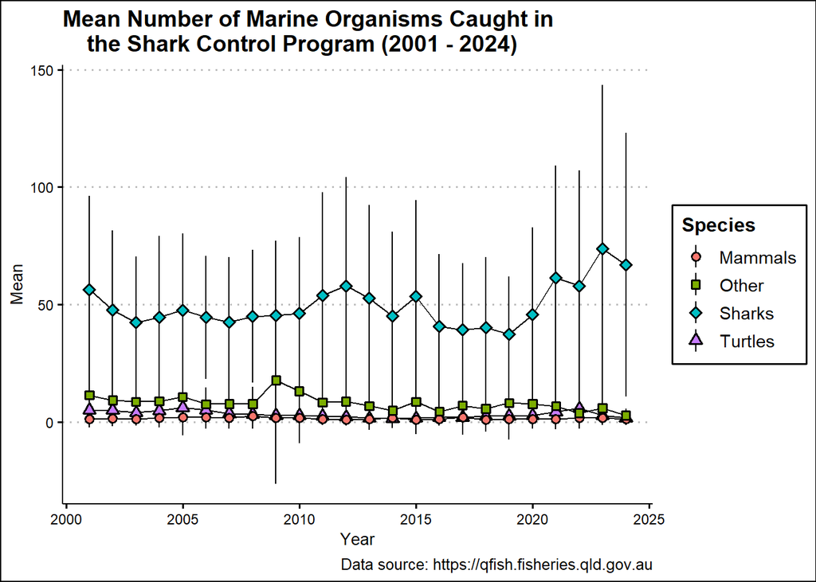

```r
ggplot(data = Total_stats, aes(x =Year, y = Mean, fill = Species, shape = Species), color = "black") +
  geom_line() +
  geom_pointrange(aes(ymin = Mean - SD, ymax = Mean + SD)) +
    scale_shape_manual(values = c(21, 22, 23, 24)) +
  theme_clean() +
  labs(
    title = "Mean Number of Marine Organisms Caught in
    the Shark Control Program (2001 - 2024)",
    caption = "Data source: https://qfish.fisheries.qld.gov.au"
  )
```

```r
ggsave("Mean Organisms Caught.jpg")
```

## Plot Data 2

For my analysis, I am particularly interested in the shark data by region. is there a particular area where sharks are caught more frequently? We can plot this as well

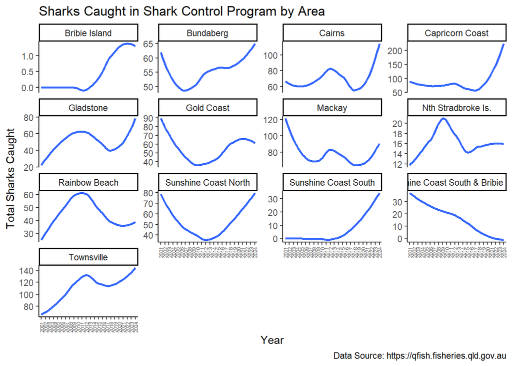

```r
ggplot(data = catch_sharks, aes(x = Year, y = Count, group = area)) +
  geom_smooth(se = F) +
  theme_classic() +
  labs(
    title = "Sharks Caught in Shark Control Program by Area",
    x = "Year", y = "Total Sharks Caught",
     fill = "Species Group",
    caption = "Data Source: https://qfish.fisheries.qld.gov.au") +
  facet_wrap(~area, scales="free_y") + # Facet wrap so each location has its own plot. free_y tells R to make y axis variable, this makes the axis more relevant to each plot.
  theme(axis.text.x = element_text(angle = 90, size = 5, vjust = 0.5)) # Change the angle of x axis labels.
```

```r
ggsave("Sharks Caught By Area.jpg")
```